# International population pyramids with ggplot2

Kyle Walker

Sunday, July 06, 2014

I’ve been working on creating static international population pyramids with [ggplot2](http://ggplot2.org/) for a project I’ve been working on and I wanted to briefly share what I’ve learned. I’ve written in greater detail about how to create interactive population pyramids in R here: http://walkerke.github.io/2014/06/rcharts-pyramids/

You can’t make a population pyramid without data; the following function `get_data` grabs the required population data from the US Census Bureau’s International Data Base and outputs a data frame in the right format for **ggplot2**. All you need is a [FIPS 10-4 country code](http://en.wikipedia.org/wiki/List_of_FIPS_country_codes) for the country you want, and then pick the year you want to visualize.

```r
library(XML)
library(reshape2)
library(ggplot2)
library(plyr)


get_data <- function(country, year) {
  c1 <- "http://www.census.gov/population/international/data/idb/region.php?N=%20Results%20&T=10&A=separate&RT=0&Y="
  c2 <- "&R=-1&C="
  url <- paste0(c1, year, c2, country)
  df <- data.frame(readHTMLTable(url))
  keep <- c(2, 4, 5)
  df <- df[,keep]
  names(df) <- c("Age", "Male", "Female")
  cols <- 2:3
  df[,cols] <- apply(df[,cols], 2, function(x) as.numeric(as.character(gsub(",", "", x))))
  df <- df[df$Age != 'Total', ]
  df$Male <- -1 * df$Male
  df$Age <- factor(df$Age, levels = df$Age, labels = df$Age)

  df.melt <- melt(df,
                   value.name='Population',
                   variable.name = 'Gender',
                   id.vars='Age' )

  return(df.melt)
}
```

Now, I can call the `get_data` function and create a population pyramid. My code was basically adapted from [this StackOverflow post](http://stackoverflow.com/questions/14680075/simpler-population-pyramid-in-ggplot2) so the credit is due to [Didzis Elferts](http://rvide.wordpress.com/) for his excellent answer. Here’s a pyramid for a fast-growing country, Nigeria, in 2014:

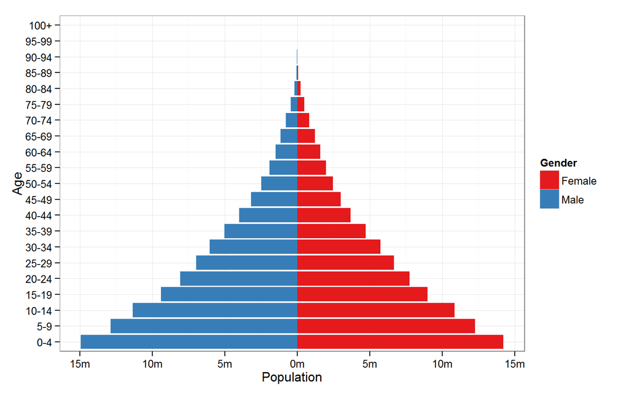

```r
nigeria <- get_data("NI", 2014)

n1 <- ggplot(nigeria, aes(x = Age, y = Population, fill = Gender)) +
  geom_bar(subset = .(Gender == "Female"), stat = "identity") +
  geom_bar(subset = .(Gender == "Male"), stat = "identity") +
  scale_y_continuous(breaks = seq(-15000000, 15000000, 5000000),
                     labels = paste0(as.character(c(seq(15, 0, -5), seq(5, 15, 5))), "m")) +
  coord_flip() +
  scale_fill_brewer(palette = "Set1") +
  theme_bw()

n1
```

You may have to fiddle with the `scale_y_continuous` arguments to get the x-axis looking just the way you want, depending on the country you’ve chosen. For contrast, here’s what an aging country, Germany, looks like:

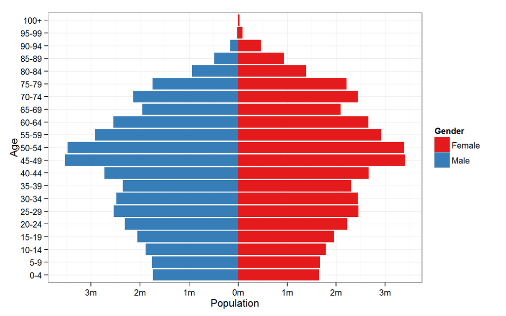

```r
germany <- get_data("GM", 2014)

g1 <- ggplot(germany, aes(x = Age, y = Population, fill = Gender)) +
  geom_bar(subset = .(Gender == "Female"), stat = "identity") +
  geom_bar(subset = .(Gender == "Male"), stat = "identity") +
  scale_y_continuous(breaks = seq(-4000000, 4000000, 1000000),
                     labels = paste0(as.character(c(4:0, 1:4)), "m")) +
  coord_flip() +
  scale_fill_brewer(palette = "Set1") +
  theme_bw()

g1
```